# Assignment 2: PCA and Clustering Analysis of a Polymerisation Reactor

CHEE4003: Special Topics A - Artificial Intelligence in Chemical Engineering

Published

September 11, 2026

## Context

Modern chemical engineering systems generate large volumes of high-dimensional data from sensors, monitoring systems, and control platforms. Analysing such data is critical for understanding process behaviour, identifying operating regimes, and improving performance, safety, and efficiency.

In this assignment, a **continuous stirred tank reactor (CSTR)** is analysed. The reactor is used for the free-radical polymerisation of **methyl methacrylate (MMA)**, with **azo-bis-isobutyronitrile (AIBN)** as the initiator and **toluene** as the solvent. This polymerisation is **highly exothermic**, requiring careful thermal management. A **cooling jacket** is therefore used to remove excess heat and regulates the system temperature.

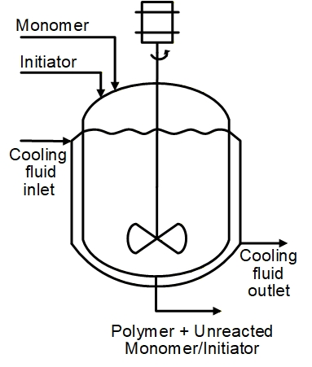

Figure 1: Process flow diagram of the CSTR used for MMA polymerisation, including feed streams, reactor, cooling jacket, and product outlet.

Reactor behaviour is governed by complex interactions between multiple variables, including:

- **Temperature**, which controls reaction kinetics and rate
- **Concentrations**, influencing reaction progress and conversion
- **Flowrates**, determining residence time and system dynamics
- **Heat generation and removal**, affecting thermal stability

These coupled effects produce **nonlinear system behaviour**, where small changes in operating conditions can lead to significant variations in performance. As a result, the reactor operates across multiple **distinct regimes**, ranging from low-reactivity (e.g., startup conditions) to high-intensity reaction states, with intermediate transition regions.

Identifying and characterising these regimes is essential for effective process design and operation, enabling improved monitoring, control, and avoidance of unstable or undesirable conditions.

## Engineering Challenge

Analysing this reactor system requires extracting meaningful insight from a **high-dimensional dataset**. In practice, engineers must address two key interconnected challenges:

**1. Dimensionality Reduction:** Reducing a complex dataset into a smaller set of variables while preserving the most important information about system behaviour.

**2. Operating Regime Identification:** Identifying groups of operating conditions that correspond to different reactor behaviours (e.g., startup, transition, steady operation).

To address these challenges, you will apply three complementary approaches to a common dataset:

- **Exploratory Data Analysis (EDA)** to understand data structure, patterns, and relationships
- **Principal Component Analysis (PCA)** to reduce dimensionality and identify dominant sources of variation
- **Clustering methods** to detect and interpret distinct operating regimes

## Assignment Aim and Learning Objectives

The aim of this assignment is to develop your ability to analyse and interpret high-dimensional chemical engineering data using data-driven techniques, and to translate these results into meaningful engineering insight.

By completing this assignment, you should be able to:

- Analyse high-dimensional engineering datasets using appropriate statistical and visualisation techniques
- Apply **Principal Component Analysis (PCA)** to reduce dimensionality and identify dominant sources of variation
- Apply **clustering methods** to identify and characterise natural groupings in data
- Interpret machine learning results in terms of **underlying system behaviour and engineering phenomena**
- Communicate findings clearly and effectively using well-structured visualisations and Python-based analysis

## Tasks

This assignment consists of four assessed components, based on the following dataset. Click on the download icon to download the dataset for your analysis.

```
pol_reactor_data.csv
```

```
F,Fi,Fj,Tr_in,Tj_in,Cm_in,Ci_in,h,Cm,Ci,D0,D1,Tr,Vj,Tj,Mw,xm
0.5511319224680011,0.03418692731485933,3.3107893775778128,363.86026593977783,291.3477096536551,3.770445181523991,8.349808086305696,0.0660024257843641,3.4201706098832667,0.48643915573618457,0.0008223508635852237,13.552718997886855,325.07348714014586,0.020781235851675548,294.4802859456573,16529.64797430473,0.0943339681853611
1.01949018417377,0.033506143118148486,3.0936604843000097,348.596835564323,289.4195859677627,6.067517149427769,10.841851202173574,0.21400114785063548,1.0232660184099613,0.0035734000162437724,0.5913963354255003,486.0599496778559,414.47653604670757,0.01711915268672204,301.8830233597955,821.7865471975697,0.8318939237240971
0.5326868945199692,0.0331162444317854,3.0752489416108983,362.56829609657484,307.1234289253301,3.355827180887978,7.813305863783171,0.0614364440516941,2.912069949245319,0.4544356066355376,0.0028961543408247844,25.615118216610227,334.65394515301455,0.01771783286590298,309.84860534995437,8784.878743269937,0.13481112200429135
1.0255568398049737,0.017867088149012243,2.6416195452929774,414.00387537508044,298.84877831207046,6.028593303781926,8.026245704718821,0.21127238425626663,1.019512499594709,2.6629772299707427e-05,0.846217333877036,492.2196611678501,448.94194154862174,0.013331887702979222,316.0515608744553,581.6962397310488,0.8326132157227915
... (884 more lines)
```

Below is a description of each of the variables in the dataset:

| Variable | Description | Units |
| --- | --- | --- |
| F | Reactor outlet volumetric flowrate | $\mathrm{m^3\,h^{-1}}$ |
| Fi | Feed inlet volumetric flowrate | $\mathrm{m^3\,h^{-1}}$ |
| Fj | Jacket flowrate | $\mathrm{m^3\,h^{-1}}$ |
| Tr_in | Inlet reactor temperature | $\mathrm{K}$ |
| Tj_in | Inlet jacket temperature | $\mathrm{K}$ |
| Cm_in | Inlet monomer concentration | $\mathrm{kmol\,m^{-3}}$ |
| Ci_in | Inlet initiator concentration | $\mathrm{kmol\,m^{-3}}$ |
| h | Reactor liquid height | $\mathrm{m}$ |
| Cm | Monomer concentration in reactor | $\mathrm{kmol\,m^{-3}}$ |
| Ci | Initiator concentration in reactor | $\mathrm{kmol\,m^{-3}}$ |
| D0 | Radical concentration | $\mathrm{kmol\,m^{-3}}$ |
| D1 | Polymer density | $\mathrm{kg\,m^{-3}}$ |
| Tr | Reactor temperature | $\mathrm{K}$ |
| Vj | Jacket volume | $\mathrm{m^3}$ |
| Tj | Jacket temperature | $\mathrm{K}$ |
| Mw | Weight-average molecular weight | $\mathrm{kg\,kmol^{-1}}$ |
| xm | Monomer conversion | $\mathrm{unitless}$ |

### Task 1 : AI Usage Statement (6 marks)

At the beginning of your submission (details below), include a statement (maximum 0.5 page) describing your use of generative AI tools (e.g., ChatGPT, Copilot, Claude).

Your statement should:

- Clearly indicate whether AI tools were used
- Describe how they were used (e.g., code generation, debugging, conceptual support)
- Critically evaluate their usefulness and limitations in the context of your work

If you did not use generative AI tools, provide an explanation for this choice.

### Task 2 : Exploratory Data Analysis (20 marks)

Using techniques introduced in **Week 1**, perform an exploratory data analysis (EDA) to understand the structure of the dataset and relationships between variables.

Your analysis should:

- Summarise the key characteristics of the dataset (e.g., ranges, distributions, variability)
- Explore relationships between variables using appropriate visualisations and statistics
- Identify patterns that may indicate different operating regimes

**TipTip**

You are encouraged to use a combination of: summary statistics, correlation analysis, scatter plots, histograms, boxplots, and pair plots to support your analysis.

#### Key Questions

Address the following questions using clear evidence from your analysis:

**1. Key Drivers of Reactor Behaviour**  
Which variable(s) appear to have the strongest influence on reactor behaviour (e.g., temperature, conversion, density)?  
Support your answer with visual and statistical evidence.

**2. Nature of Variable Relationships**  
Do the relationships between key variables appear **linear or nonlinear**?  
Provide justification using plots and trends observed in the data.

**3. Identification of Patterns**  
Does the dataset show evidence of **distinct patterns or structure** in the data?  
Describe any patterns or separations observed in the data, and identify the variables that best distinguish these patterns.

**ImportantImportant**

Your visualisations should be **purposeful and clearly interpreted**. The goal is not only to present plots, but to extract meaningful insights that **inform and justify your PCA and clustering analysis** in subsequent tasks.

### Task 3 : Principal Component Analysis - PCA (37 marks)

Using techniques introduced in **Week 6**, apply Principal Component Analysis (PCA) to reduce the dimensionality of the dataset and identify the dominant patterns governing reactor behaviour.

Your analysis should:

- Prepare the dataset appropriately (e.g., standardisation of variables)
- Apply PCA and evaluate the **explained variance**
- Interpret the meaning of the principal components using the **loadings**
- Relate PCA results to the underlying **physical behaviour of the reactor**

**Tip**

Use a combination of scree plots (explained variance), cumulative variance curves, loading plots, and/or PCA biplots to support your analysis. Focus on selecting an appropriate number of components, identifying the key variables driving each principal component. Link the principal components to **engineering meaning** (e.g., physical mechanisms, process behaviour, or system variables).

#### Key Questions

Address the following questions using clear evidence from your analysis:

**1. Dimensionality Reduction and Explained Variance**  
How effective is PCA at capturing the variance within the dataset?  
How many principal components are required to capture most of the variance in the dataset (e.g., 80–90%)?  
Evaluate whether PCA enables an effective reduction in dimensionality.

**2. Interpretation of Principal Components**  
What do the main principal components represent?

- **PC1:** Which variables contribute most strongly to PC1? What type of variation does this component capture?
- **PC2:** Which variables contribute most strongly to PC2? How does this component differ from PC1 in the variation it captures?

Support your answer using scores and loadings.

**3. Engineering Interpretation**  
Based on your PCA results, what are the main factors controlling reactor operation?  
Explain how the dominant patterns identified by PCA relate to the underlying chemical and physical processes occurring in the reactor. Discuss what these patterns suggest about different operating conditions, reactor performance, and potential operating regimes.

### Task 4 : Clustering Analysis (37 marks)

Using techniques introduced in **Week 7**, apply clustering methods to the PCA-transformed dataset, using **only the first two principal components (PC1 and PC2)**, to identify distinct operating regimes in the reactor data.

The following clustering methods should be used:

- K-Means Clustering Algorithm
- Density-Based Spatial Clustering of Applications with Noise (DBSCAN)
- Gaussian Mixture Model (GMM)

Your analysis should:

- Apply each clustering method to the **reduced-dimensional dataset**
- Clearly **justify the choice of parameters** (e.g., number of clusters, epsilon, minimum samples)
- **Visualise the clustering results**, for example using PCA score plots coloured by cluster labels
- **Interpret the identified clusters** in terms of reactor behaviour

**TipTip**

Use appropriate metrics to guide parameter selection, such as **silhouette score** and **inertia** (for K-Means), and **AIC or BIC** (for GMM). For **DBSCAN**, silhouette score can be used (computed on non-noise points), but should be interpreted with caution due irregular cluster shapes.

#### Key Questions

Address the following questions using clear evidence from your analysis:

**1. Cluster Identification and Structure**

For each clustering method:

- How many clusters are identified?
- Do the clusters show clear separation or overlap in the PCA space?
- What are the main characteristics of the cluster structure (e.g., compact, elongated, irregular)?
- For DBSCAN, are any points classified as **noise**, and how are they distributed?

**2. Comparison of Clustering Methods**

Compare the performance of K-Means, GMM, and DBSCAN:

- How do the clustering results differ between methods?
- Which method provides the most appropriate clustering solution for this dataset?
- Which method captures more complex or subtle patterns?

Justify your answer using appropriate metrics, visualisations, and cluster characteristics.

**3. Identification of Operating Regimes**

Using the results from **one selected clustering method**, determine whether the clusters correspond to distinct operating regimes within the reactor.

- Which variables appear to distinguish the identified regimes?
- How do the regimes differ in terms of their observed process conditions (e.g., low vs high temperature, low vs high molecular weight, or differences in flow and cooling conditions)?

Support your answer using visual evidence and summary statistics.

**4. Engineering Interpretation**

Interpret the identified operating regimes in terms of reactor behaviour.

- What operating condition does each regime represent (e.g., startup, low-conversion operation, high-conversion operation, transition regime)?
- What insights do these regimes provide about reactor performance and operation?
- For DBSCAN, comment on the physical significance of any noise points (if applicable) and whether they indicate outliers, transitions between regimes

**ImportantImportant**

You must compare all three clustering methods using the same PCA-reduced dataset. Focus on **justified parameter selection**, not exhaustive grid searches. Emphasis is on **interpretation and insight**, not just applying algorithms. Clearly link clustering results to **physical reactor behaviour**.

## Submission

Submit your work via **Gradescope**. Your submission must include:

### 1. Report

Submit a single, well-structured report of **6–9 pages** (use the space effectively). The report should be **clear, concise, and professionally presented**, and must include:

- Relevant **figures**, **tables**, and **results**
- **Complete written responses** to all questions
- Interpretation of results and justification of conclusions

**TipTip**

Use a **small number of high-quality, informative figures and tables**. Avoid repetitive or unnecessary figures.

**ImportantReport Requirements**

- Ensure all figures and tables are **clearly labelled** and **referenced in the text**
- Present results **succinctly**, emphasising **interpretation and insight** rather than raw outputs
- Marks are awarded for both **technical accuracy** and **engineering insight**

### 2. Code

Submit a single **Python file** called `a2.py`. The code must be:

- **Well-organised** and **easy to read**
- Written using **meaningful** variable and function names
- **Properly commented** to explain key steps

**ImportantCode Requirements**

The submitted code script must:

- **Execute successfully** in the Gradescope autograder environment.
- **Generate and reproduce** all figures, analyses, and results presented in the report.
- **Be tested in Gradescope before submission**.

Students are responsible for ensuring that their code runs correctly and produces reproducible results in the Gradescope assessment environment.

Failure to submit your code script or submission of code that does not execute successfully and reproduce the reported results, will result in a **penalty of 50% of the total assignment mark**. This penalty will be applied regardless of the quality of the accompanying report.

## Marking Rubric

Marks are awarded based on the quality of analysis, interpretation, justification, and engineering insight. Higher marks require conclusions to be supported by appropriate evidence and clearly communicated.

### Assessment Criteria

| Task | Criterion | Description | Marks |
| --- | --- | --- | --- |
| **AI Usage Statement** | AI Usage Statement | Describes AI use (or non-use) and reflects on its benefits and limitations. | 6 |
| **Exploratory Data Analysis** | Data Exploration and Summary | Explores dataset characteristics using appropriate statistics. | 5 |
|  | Visualisation and Relationships | Uses effective visualisations to investigate patterns and relationships. | 5 |
|  | Interpretation of Reactor Behaviour | Identifies and explains key trends using evidence from the data. | 5 |
|  | Engineering Insight and Operating Patterns | Interprets findings in an engineering context and identifies operating patterns. | 5 |
| **Principal Component Analysis (PCA)** | Data Preparation and PCA Implementation | Prepares data appropriately and applies PCA correctly. | 8 |
|  | Explained Variance and Dimensionality Reduction | Evaluates explained variance and dimensionality reduction. | 10 |
|  | Interpretation of Principal Components | Interprets principal components using loadings and variable contributions. | 10 |
|  | Engineering Interpretation and Insight | Relates PCA results to reactor behaviour and system variation. | 9 |
| **Clustering Analysis** | Cluster Development and Parameter Selection | Applies clustering methods and justifies parameter selection. | 10 |
|  | Cluster Evaluation and Method Comparison | Evaluates and compares clustering results across methods. | 10 |
|  | Interpretation of Operating Regimes | Interprets clusters and identifies variables distinguishing regimes. | 8 |
|  | Engineering Insight and Practical Implications | Explains clustering results in terms of reactor operation and performance. | 9 |
| **Total** |  |  | **100** |

### Performance Levels

| Level | Percentage | General Descriptor |
| --- | --- | --- |
| **Exemplary** | **100%** | Demonstrates outstanding achievement of the criterion. Work is of exceptional quality, accuracy, completeness, and insight. |
| **Excellent** | **90%** | Demonstrates a strong achievement of the criterion. Work is accurate, thorough, and well-developed, with only minor limitations. |
| **Very Good** | **80%** | Demonstrates very good achievement of the criterion. Work is effective, accurate, and well-developed, with minor omissions or weaknesses. |
| **Good** | **70%** | Demonstrates competent achievement of the criterion. Work addresses most requirements appropriately, although depth, quality, accuracy, or completeness may be limited in places. |
| **Satisfactory** | **60%** | Demonstrates a basic achievement of the criterion. Work addresses key requirements but lacks consistency, depth, detail, or completeness. |
| **Mixed** | **50%** | Demonstrates partial achievement of the criterion. Work contains a mixture of strengths and weaknesses, including incomplete, inaccurate, or underdeveloped elements. |
| **Partially Correct** | **40%** | Demonstrates limited achievement of the criterion. Some requirements are addressed, but significant errors, omissions, or weaknesses reduce overall quality. |
| **Attempted** | **20%** | Demonstrates minimal achievement of the criterion. Work shows limited engagement with the requirements and provides little evidence of attainment. |
| **Not Attempted** | **0%** | Demonstrates no achievement of the criterion. The criterion has not been addressed, or no assessable evidence is provided. |